# Exercise 2: Bayesian inference with elementary Markov Chain sampling

Eawag Summer School in Environmental Systems Analysis (back to overview)

**Objectives**

- Implement the Metropolis algorithm for a one-parameter model, and apply it to generate a posterior parameter sample, for the model “survival”.
- Calculate a Markov chain sample of the posterior model parameter distribution. Starting from a first guess jump distribution, construct a simple algorithm to improve the jump distribution for higher efficiency.
- Use graphical analysis and convergence tests to asses the quality of the Markov chain samples.

# 1. Implement an elementary Markov Chain sampler ★

In this exercise, you will write your own code to implement the most elementary MCMC sampler, the Metropolis algorithm for one dimension. MCMC samplers can be used to sample from any distribution, and they are not linked to Bayesian concepts per se. In Bayesian inference, however, they are especially useful to sample from the posterior distribution. You will apply your self-coded sampler to sample from the posterior distribution of the one-parameter model “survival”, given the observed data in the file `model_survival.csv`.

## Before you get started

We want to use the model “Survival” from yesterday’s exercise and the data `model_survival.csv` to test our sampler. The experiment was started with `N=30` individuals (this information is not contained in the data set).

### Reading and plotting the data

It’s always a good idea to look at the data first.

#### Hints

##### R

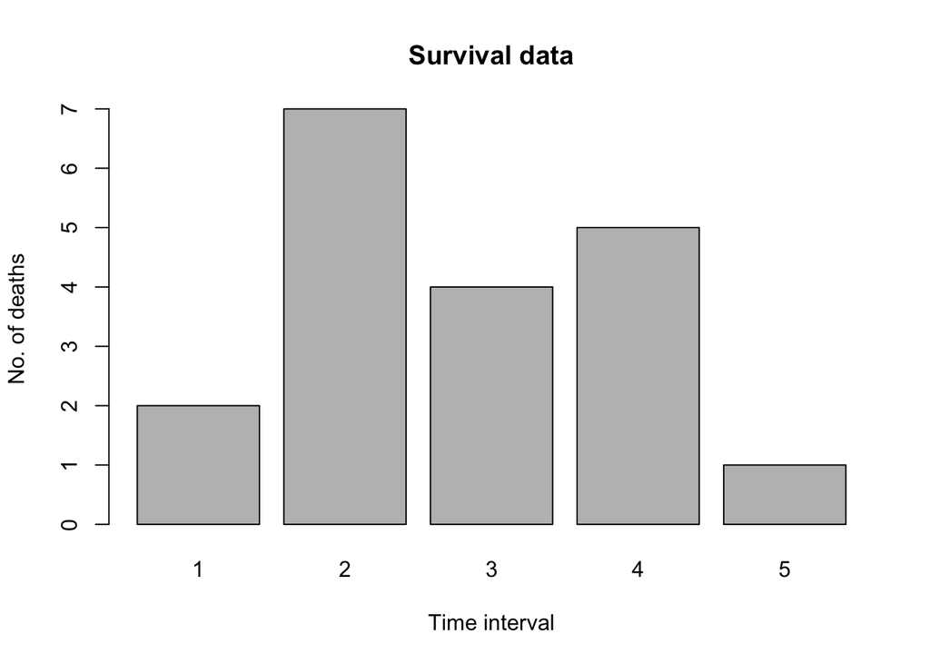

```r
data.survival <- read.table("../../data/model_survival.csv", header=TRUE)
barplot(data.survival$deaths, names=data.survival$time,
        xlab="Time interval", ylab="No. of deaths",
        main="Survival data")
```

##### Julia

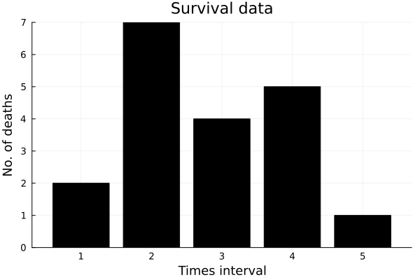

```julia
using DataFrames
import CSV
using Plots
survival_data = CSV.read("../../data/model_survival.csv",
                         DataFrame);

bar(survival_data.deaths,
    labels = false,
    xlabel = "Times interval",
    ylabel = "No. of deaths",
    title = "Survival data")
```

##### Python

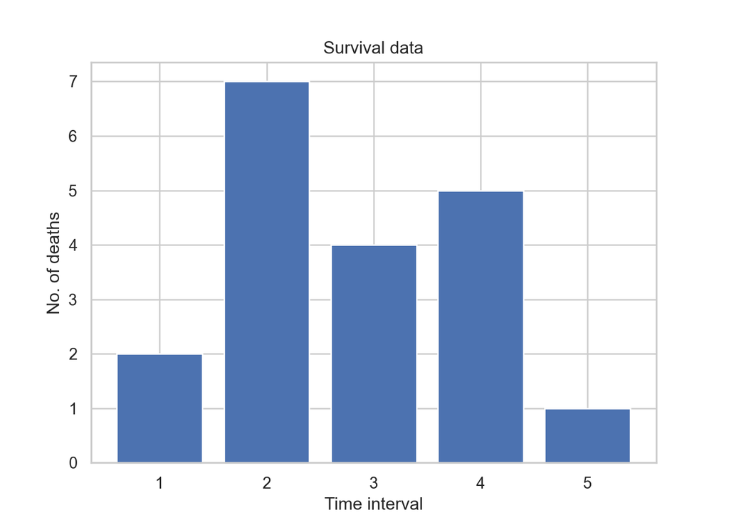

```python
import pandas as pd
import matplotlib.pyplot as plt

# Loading data
# Specify the path to the CSV file
file_path = r"../../data/model_survival.csv"

# Load the CSV file into a pandas DataFrame
data_survival = pd.read_csv(file_path, sep=" ")

plt.bar(data_survival['time'], data_survival['deaths'])

# Set the x and y labels and title
plt.xlabel("Time interval")
plt.ylabel("No. of deaths")
plt.title("Survival data")

# Display the plot
plt.show()
```

### Defining the likelihood, prior, and posterior

In the next step we will need the posterior density (or more accurately: a function that is proportional to the posterior density) for the model “survival” because
$$p(\lambda|y)\propto p(\lambda,y) = p(y|\lambda)p(\lambda) \; .$$
This means that we need the likelihood function $p(y|\lambda)$ and the prior $p(\lambda)$.

Remember to set `N=30`.

#### Likelihood

##### R

The likelihood is given below (copied from Exercise 1):

```r
loglikelihood.survival <- function(y, N, t, par){

    ## Calculate survival probabilities at measurement points
    ## and add zero "at time-point infinity":
    S <- exp(-par*c(0,t))
    S <- c(S,0)

    ## Calculate probabilities to die within observation windows:
    p <- -diff(S)

    ## Add number of survivors at the end of the experiment:
    y <- c(y, N-sum(y))

    ## Calculate log-likelihood of multinomial distribution at point y:
    LL <- dmultinom(y, prob=p, log=TRUE)

    return(LL)
}
```

##### Julia

The likelihood can be implemented like this, copied from Exercise 1.

```julia
using Distributions

function loglikelihood_survival(N::Int, t::Vector, y::Vector, λ)
    S = exp.(-λ .* t)
    S = [1; S; 0]
    p = -diff(S)
    ## Add number of survivors at the end of the experiment:
    y = [y; N-sum(y)]

    logpdf(Multinomial(N, p), y)
end
```

##### Python

The likelihood can be implemented like this, copied from Exercise 1.

```python
def loglikelihood_survival(y, N, t, par):
    # Calculate survival probabilities at measurement points
    # and add zero "at time-point infinity":
    S = np.exp(-par * np.concatenate(([0], t)))
    S = np.concatenate((S, [0]))

    # Calculate probabilities to die within observation windows:
    p = -np.diff(S)

    # Add number of survivors at the end of the experiment:
    y = np.concatenate((y, [N - np.sum(y)]))

    # Calculate log-likelihood of multinomial distribution at point y:
    LL = multinomial.logpmf(y, n=N, p=p)

    return LL
```

### Prior

The parameter $\lambda$ must be positive. Furthermore, we know that values around 0.3 are quite plausible, and that values below 0.1 and above 0.7 are pretty unlikely. Which distribution would you choose for the prior?

Implement a function that returns the logarithm of a probability density of the prior distribution for $\lambda$.

#### R

You can use a `lognormal` prior distribution by understanding and filling-in the block below.

```r
# we use a lognormal distribution, which naturally accounts
# for the fact that lambda is positive

logprior.survival <- function(par){

  # a mean and standard deviation that approximate the prior information given above are:
  mu <- ???    # since the distribution is skewed, choose it higher than 0.3 (the mode)
  sigma <- ??? # a value similar to mu will do

  # calculate the mean and standard deviation in the log-space
  meanlog <- log(mu) - 1/2*log(1+(sigma/mu)^2) #
  sdlog <- sqrt(log(1+(sigma/mu)^2))           #

  # Use these to parameterize the prior
  dlnorm(???)
}
```

#### Julia

You can use a `lognormal` prior distribution by understanding and filling-in the block below.

```julia
function logprior_survival(λ)
    # a mean and standard deviation that approximate the prior information given above are:
    m = ?       # the distribution is skewed, choose a mean higher than 0.3 (the mode)
    sd = ?      # a value similar to the mean will do

    # calculate the mean and standard deviation in the log-space
    μ = log(m/sqrt(1+sd^2/m^2))
    σ = sqrt(log(1+sd^2/m^2))

    # Use these to parameterize the prior
    return logpdf(Normal(???), ???)
end
```

#### Python

You can use a `lognormal` prior distribution by understanding and filling-in the block below.

```python
def logprior_survival(par):
    # Define mean and standard deviation that approximate the prior information given
    mu = 0.6    # Since the distribution is skewed, choose it higher than 0.3 (the mode)
    sigma = 0.7 # A value similar to mu will do

    # Calculate the mean and standard deviation in the log-space
    meanlog = np.log(mu) - 0.5 * np.log(1 + (sigma / mu)**2)
    sdlog = np.sqrt(np.log(1 + (sigma / mu)**2))

    # Calculate the log prior using log-normal distribution
    log_prior = lognorm.logpdf(par, s=sdlog, scale=np.exp(meanlog))

    return log_prior
```

### Posterior

Finally, define a function that evaluates the density of the log posterior distribution.

This function should take the data from the file `model_survival.csv` and a parameter value as inputs.

Check what happens if you pass an “illegal”, i.e. negative parameter value. The function must not crash in this case.

#### R

```r
log.posterior <- function(par, data) {
    ...
}
```

#### Julia

```julia
function logposterior_survival(λ, data)
    return ...
end
```

#### Python

```python
def logposterior_survival(par, data):
    # Calculate log-likelihood
    log_likelihood = ??

    # Calculate log-prior
    log_prior = ??

    # Calculate log-posterior
    log_posterior = log_likelihood + log_prior

    return log_posterior
```

## Code your own Markov Chain Metropolis sampler

Implement your own elementary Markov Chain Metropolis sampler and run it with the posterior defined above for a few thousand iterations. You can find a description of the steps needed in Carlo’s slides.

### R

```r
#  set sample size (make it feasible)
sampsize <- 5000

# Create an empty matrix to hold the chain:
chain <- matrix(nrow=sampsize, ncol=2)
colnames(chain) <- c("lambda","logposterior")

# Set start value for your parameter:
par.start <- ???

# compute logosterior value of of your start parameter
chain[1,] <- ???

# Run the MCMC:
for (i in 2:sampsize){

  # Propose new parameter value based on previous one
  # (choose a propsal distribution):
  par.prop <- ???

  # Calculate logposterior of the proposed parameter value:
  logpost.prop <- ???

  # Calculate acceptance probability by using the Metropolis criterion min(1, ... ):
  acc.prob <- ???

  # Store in chain[i,] the new parameter value if accepted, or re-use the old one if rejected:
  if (runif(1) < acc.prob){
    ???
   } else {
    ????
   }
}
```

### Julia

```julia
# set your sampsize
sampsize = 5000

# create empty vectors to hold the chain and the log posteriors values
chain = Vector{Float64}(undef, sampsize);
log_posts = Vector{Float64}(undef, sampsize);

# Set start value for your parameter
par_start = ???

# compute logosterior value of of your start parameter
chain[1] = ???
log_posts[1] = ???

# Run the MCMC:
for i in 2:sampsize

  # Propose new parameter value based on previous one (choose a propsal distribution):
  par_prop = ???

  # Calculate logposterior of the proposed parameter value:
  logpost_prop = ???

  # Calculate acceptance probability by using the Metropolis criterion min(1, ... ):
  acc_prob = ???

  # Store in chain[i] the new parameter value if accepted,
  # or re-store old one if rejected:
  if rand() < acc_prob # rand() is the same as rand(Uniform(0,1))
    ???
  else # if not accepted, stay at the current parameter value
    ???
  end
end
```

### Python

```python
# Set sample size (make it feasible)
sampsize = 5000

# Create an empty array to hold the chain
chain = np.zeros((sampsize, 2))
# Define column names
column_names = ['lambda', 'logposterior']

# Set start value for your parameter
par_start = {'lambda': 0.5}

# Compute posterior value of the first chain using the start value
# of the parameter and the logprior and loglikelihood functions already defined
chain[0, 0] = par_start['lambda']
chain[0, 1] = logposterior_survival(par_start['lambda'], data_survival)

# Run the MCMC
for i in range(1, sampsize):
    # Propose a new parameter value based on the previous one (think of proposal distribution)
    par_prop = ??

    # Calculate log-posterior of the proposed parameter value (use likelihood and prior)
    logpost_prop = ??

    # Calculate acceptance probability
    acc_prob = ??

    # Store in chain[i, :] the new parameter value if accepted, or re-use the old one if rejected
    if np.random.rand() < acc_prob:
        chain[i, :] = [par_prop, logpost_prop]
    else:  # if not accepted, stay at the current parameter value
        chain[i, :] = chain[i - 1, :]

# If you want to convert the array to a DataFrame for further analysis
df_chain = pd.DataFrame(chain, columns=column_names)
```

Experiment with you sampler: - Plot the resulting chain. Does it look reasonable? - Test the effect of different jump distribution. - Find the value of $\lambda$ within your sample, for which the posterior is maximal. - Create a histogram or density plot of the posterior sample. Look at the chain plots to decide how many the burn-in sample you need to remove.

# 2. Sample from the posterior for the monod model ★

The main difference of the “Monod” compared to the “Survival” model is that it has more than one parameter that we would like to infer.

You can either generalize our own Metropolis sampler to higher dimensions or use a sampler from a package.

## Read data

We use the data `model_monod_stoch.csv`:

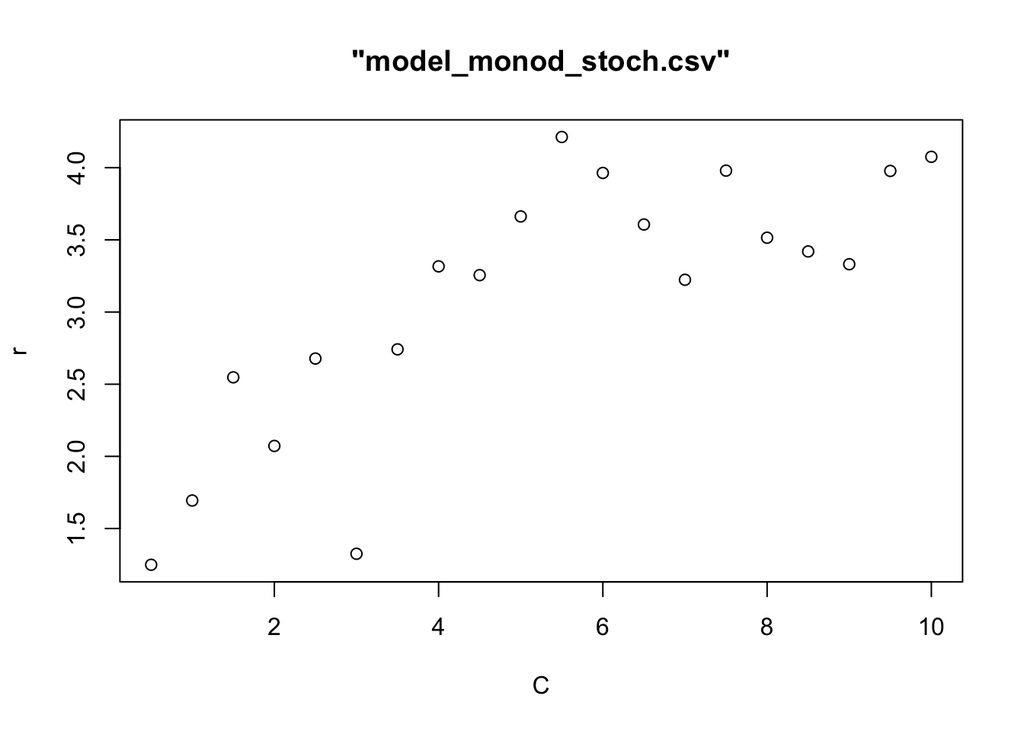

```r
data.monod <- read.table("../../data/model_monod_stoch.csv", header=T)
plot(data.monod$C, data.monod$r, xlab="C", ylab="r", main='"model_monod_stoch.csv"')
```

## Define likelihood, prior, and posterior

Again, we need to prepare a function that evaluates the log posterior. You can use the templates below.

### R

```r
# Logprior for model "monod": lognormal distribution

prior.monod.mean <- 0.5*c(r_max=5, K=3, sigma=0.5)
prior.monod.sd   <- 0.5*prior.monod.mean

logprior.monod <- function(par,mean,sd){

    sdlog    <- ???
    meanlog  <- ???

    return(sum(???)) # we work log-space, hence sum over multiple independent data points
}

# Log-likelihood for model "monod"

loglikelihood.monod <- function( y, C, par){

  # deterministic part:
  y.det <- ???

  # Calculate loglikelihood:
  return( sum(???) )
}

# Log-posterior for model "monod" given data 'data.monod' with layout 'L.monod.obs'

logposterior.monod <- function(par) {
  logpri <- logprior.monod(???)
  if(logpri==-Inf){
    return(-Inf)
  } else {
    return(???) # sum log-prior and log-likelihood
  }
}
```

### Julia

```julia
include("../../models/models.jl") # load monod model
using ComponentArrays
using Distributions

# set parameters
par = ComponentVector(r_max = 5, K=3, sigma=0.5)

prior_monod_mean = 0.5 .* par
prior_monod_sd = 0.25 .* par

# Use a lognormal distribution for all model parameters
function logprior_monod(par, m, sd)
    m = ...
    σ = ...
    return sum(...) # sum because we are in the log-space
end


# Log-likelihood for model "monod"
function loglikelihood_monod(par::ComponentVector, data::DataFrame)
    y_det = ...
    return sum(...)
end

# Log-posterior for model "monod"
function logposterior_monod(par::ComponentVector)
    logpri = logprior_monod(...)
    if logpri == -Inf
        return ...
    else
        return ...    # sum log-prior and log-likelihood
    end
end
```

### Python

```python
# Define the prior mean and standard deviation
prior_monod_mean = 0.5 * np.array([5, 3, 0.5])  # r_max, K, sigma
prior_monod_sd = 0.5 * prior_monod_mean

# Log prior for Monod model
def logprior_monod(par, mean, sd):
    """
    Log-prior function for the Monod model.

    Parameters:
    - par: array-like, the parameters to evaluate the prior (e.g., ['r_max', 'K', 'sigma'])
    - mean: array-like, the mean values for the parameters
    - sd: array-like, the standard deviation values for the parameters

    Returns:
    - log_prior: the sum of log-prior values calculated from the log-normal distribution
    """

    # Calculate sdlog and meanlog for log-normal distribution
    var = ??
    sdlog = ??
    meanlog = ??

    # Calculate the sum of log probabilities from the log-normal distribution
    log_prior = np.sum(??)

    return log_prior

def loglikelihood_monod(y, C, par):
    """
    Log-likelihood function for the Monod model.

    Parameters:
    - y: observed growth rates
    - C: substrate concentrations
    - par: array-like, the parameters ('r_max', 'K', 'sigma')

    Returns:
    - log_likelihood: the sum of log-likelihood values
    """
    # Calculate growth rate using Monod model
    y_det = ??

    # Calculate log-likelihood assuming a normal distribution
    log_likelihood = np.sum(??)

    return log_likelihood

def logposterior_monod(par, data, prior_mean, prior_sd):
    """
    Log-posterior function for the Monod model.

    Parameters:
    - par: array-like, the parameters ('r_max', 'K', 'sigma')
    - data: pandas DataFrame, the data containing observed growth rates and substrate concentrations
    - prior_mean: array-like, the mean values for the parameters
    - prior_sd: array-like, the standard deviation values for the parameters

    Returns:
    - log_posterior: the log posterior probability
    """
    lp = ??
    if np.isfinite(lp):
        log_posterior = lp + ??
        return log_posterior
    else:
        return -np.inf
```

## Create initial chain

First run an initial chain, which most likely has not yet a good mixing.

For the jump distribution, assume a diagonal covariance matrix with reasonable values. The diagonal covariance matrices (with zero-valued off-diagonal entries) correspond to independent proposal distribution.

### R

The code below uses the function `adaptMCMC::MCMC`. If the adaptation is set to `FALSE`, this corresponds to the basic Metropolis sampler. Of course, feel free to use your own implementation instead!

```r
library(adaptMCMC)


## As start values for the Markov chain we can use the mean of the prior
par.start <- c(r_max=2.5, K=1.5, sigma=0.25)


## sample
monod.chain <- adaptMCMC::MCMC(p  = ...,
                               n = ...,
                               init = ...,
                               adapt = FALSE # for this exercise we do not want to use automatic adaptation
                               )
monod.chain.coda <- adaptMCMC::convert.to.coda(monod.chain) # this is useful for plotting
```

Plot the chain and look at the rejection rate of this chain to gain information if the standard deviation of the jump distribution should be increased (if rejection frequency is too low) or decreased (if it was too high). What do you think?

```r
monod.chain$acceptance.rate

plot(monod.chain.coda)

pairs(modod.chain$samples)
```

### Julia

The package [`KissMCMC`](https://github.com/mauro3/KissMCMC.jl) provides a very basic Metropolis sampler. Of course, feel free to use your own implementation instead!

```julia
using KissMCMC: metropolis
using Distributions
using LinearAlgebra: diagm

# define a function that generates a proposal given θ:
Σjump = diagm(ones(3))
sample_proposal(θ) = θ .+ rand(MvNormal(zeros(length(θ)), Σjump))

# run sampler
samples, acceptance_ratio, lp = metropolis(logposterior_monod,
                                           sample_proposal,
                                           par;
                                           niter = 10_000,
                                           nburnin = 0);

## for convenience we convert our samplers in a `MCMCChains.Chains`
using MCMCChains
using StatsPlots
chn = Chains(samples, labels(par))

plot(chn)
corner(chn)

Array(chn)                      # convert it to normal Array
```

### Python

For this exercise, we provide the function below, which is simply an adaptation of the chain you wrote in exercise 1. In the function doc strings you have an overview of how to run your function for your model. Of course, feel free to use your own implementation instead!

```python
def run_mcmc_monod(logposterior_func, data, prior_mean, prior_sd, par_init, sampsize=5000, scale=np.diag([1, 1, 1])):
    """
    Run MCMC for the model.

    Parameters:
    - logposterior_func: function, the log-posterior function to use
    - data: pandas DataFrame, the data containing observed growth rates and substrate concentrations
    - prior_mean: array-like, the mean values for the parameters
    - prior_sd: array-like, the standard deviation values for the parameters
    - par_init: array-like, the initial parameter values
    - sampsize: int, the number of samples to draw (default: 5000)
    - scale: array-like, the covariance matrix for the proposal distribution

    Returns:
    - chain: array, the chain of parameter samples and their log-posterior values
    - acceptance_rate: float, the acceptance rate of the MCMC run
    """
    chain = np.zeros((sampsize, len(par_init) + 1))
    chain[0, :-1] = par_init
    chain[0, -1] = logposterior_func(par_init, data, prior_mean, prior_sd)

    accepted = 0
    for i in range(1, sampsize):
        par_prop = chain[i-1, :-1] + np.random.multivariate_normal(np.zeros(len(par_init)), scale)
        logpost_prop = logposterior_func(par_prop, data, prior_mean, prior_sd)
        acc_prob = min(1, np.exp(logpost_prop - chain[i-1, -1]))

        if np.random.rand() < acc_prob:
            chain[i, :-1] = par_prop
            chain[i, -1] = logpost_prop
            accepted += 1
        else:
            chain[i, :] = chain[i-1, :]

    acceptance_rate = accepted / sampsize

    return chain, acceptance_rate
```

Convert the chain to a data frame so you can improve the visualization of the results

```python
# Convert the results into a dataframe
df_chain = pd.DataFrame(chain, columns=['r_max', 'K', 'sigma', 'logposterior']) # this is useful for plotting

# Visualize the results
df_chain.describe()
```

## Improve jump distribution

The plot of the previous chain gives us some indication how a more efficient jump distribution could look like.

- Try to manually change the variance of the jump distribution. Can we get better chains?
- Use the previous chain and estimate its covariance. Does a correlated jump distribution work better?

### R

The function `adaptMCMC::MCMC` takes argument `scale` to modify the jump distribution:

```
scale: vector with the variances _or_ covariance matrix of the jump
          distribution.
```

### Julia

Adapt the covariance matrix `Σjump` of the jump distribution that is used in the function `sample_proposal`.

### Python

The provided function “run_mcmc_monod” takes argument `scale` to modify the jump distribution.

## Residual Diagnostics

The assumptions about the observation noise should be validated. Often we can do this by looking at the model residuals, that is the difference between observations and model prediction.

- Find the parameters in the posterior sample that correspond to the largest posterior value (the so called maximum posterior estimate, MAP).
- Run the deterministic “Monod” model with this parameters and analyze the residuals.
  - Are they normally distributed?
  - Are they independent
  - Are they centered around zero?
  - Do you see any suspicious structure?

### R

The function `qqnorm` and `acf` can be helpful.

### Julia

The function `StatsBase.autocor` and `StatPlots.qqnorm(x)` can be helpful.

### Python

The function `acf` from `statsmodels.tsa.stattools` and the function `stats` from `scipy` might be useful.

# 3. Sample from the posterior for the growth model

The goal is to sample for the posterior distribution of the “Growth” model. This task is very similar to the previous one except that we provide less guidance.

1. Read data `model_growth.csv`
2. Define likelihood, prior, and posterior. What assumptions do you make?
3. Run MCMC sampler
4. Check convergence and mixing. If needed, modify the jump distribution
5. Perform residual diagnostics. Are the assumption of the likelihood function ok?